# Predicting Refund Requests in Indian E-Commerce Deliveries

## Phase 2: Predictive Modeling

**Group ID:** 7  
**Team Members:**

- Saurabh Sharma *(s4038560)*
- Shivam Shinde *(s3994666)*

### Task 1: Introduction

1.1 Phase 1 Summary

1.2 Report Overview

1.3 Overview of Methodology

### Task 2: Predictive Modeling

2.1 Feature Selection

2.2 Model Fitting and Tuning

a) Logistic Regression

- Business Insight
- Confusion Matrix
- Hyperparameter Tuning Interpretation

b) Decision Tree

- Business Insight
- Confusion Matrix
- Hyperparameter Tuning Interpretation

c) Support Vector Mechanism (SVM)

- Business Insight
- Confusion Matrix
- Hyperparameter Tuning Interpretation

d) K Nearest Neighbour (KNN)

- Business Insight
- Confusion Matrix
- Hyperparameter Tuning Interpretation

2.2.5 Neural Network Model Fitting and Tuning

2.3 Model Comparison

2.4 Justification of Algorithm Results: Sentiment Analysis

- Distribution of Sentiment Polarity Scores
- Sentiment Scores by Refund Status
- Average Sentiment by Platform
- Justification: Sentiment Analysis Visual Insights

### Task 3: Critiques and Limitations

### Task 4: Summary and Conclusions

4.1 Project Summary

4.3 Conclusion

## Task 1 - Introduction

### 1.1 Phase 1 Summary

In Phase 1, we focused on preparing a clean and structured dataset to enable predictive modeling in Phase 2. The dataset captured key aspects of Indian e-commerce grocery deliveries, including platform used, delivery time, order value, service rating, product category, customer feedback, and refund request status. The target variable was `Refund Requested`, a binary indicator denoting whether a customer sought a refund.

**Key tasks performed:**

- **Data Cleaning & Preprocessing**: Removed ID-like fields (e.g., `Order ID`, `Customer ID`), handled missing values, converted time-related fields into numerical format, encoded binary/categorical variables, and treated outliers using percentile clamping.
- **Exploratory Data Analysis (EDA)**: Conducted univariate, bivariate, and multivariate visual analysis. Key insights included high refund rates in categories like *Personal Care* and *Snacks & Beverages*, a high refund count on platforms like *Swiggy Instamart*, and surprisingly frequent refund requests despite high service ratings.
- **Visualization**: Created 11 insightful visual plots, including correlation heatmaps and categorical breakdowns by platform and product.

These efforts established the groundwork for supervised learning models to be built in Phase 2, where we aim to predict refund behavior and uncover feature importance using classification algorithms.

### 1.2 Report Overview

This Phase 2 report presents a comprehensive predictive modeling pipeline applied to an e-commerce refund prediction dataset. Building on the data preprocessing and exploratory analysis completed in Phase 1, this report applies advanced machine learning techniques including feature selection, model training, hyperparameter tuning, and evaluation using various classifiers. Four models—Logistic Regression, Decision Tree, Support Vector Machine (SVM), and k-Nearest Neighbors (KNN)—are rigorously tested and fine-tuned using GridSearchCV, with their performance visualized through confusion matrices and hyperparameter tuning plots. Additionally, a sentiment analysis component is introduced to enhance interpretability, offering a business-focused justification for the high classification accuracy observed.

The report includes all necessary stages of a robust machine learning workflow: preprocessing pipelines, feature selection using `SelectKBest`, cross-validation, model tuning, evaluation using classification metrics, and visual analysis. It concludes with model comparisons and a critical reflection on the strengths and limitations of the chosen methods, providing insights into the business implications of the results.

### 1.3 Overview of Methodology

The predictive modeling methodology adopted in this project follows a structured machine learning pipeline, beginning with data preprocessing and culminating in evaluation and model comparison. After completing Phase 1 tasks, which involved data cleaning and exploration, Phase 2 focused on constructing, tuning, and evaluating classification models to predict whether a customer would request a refund.

Four supervised classification algorithms were implemented:

- **Logistic Regression** for its interpretability and performance on linearly separable data,
- **Decision Tree** for its ability to handle complex feature interactions and rank feature importance,
- **Support Vector Machine (SVM)** for optimal margin separation,
- **K-Nearest Neighbors (KNN)** for its simplicity and proximity-based decision-making.

Each model underwent hyperparameter tuning via `GridSearchCV` with 5-fold cross-validation to optimize performance. The best-performing parameters were selected, and final predictions were evaluated using classification reports and confusion matrices. Additional evaluation was supported by tuning visualizations and a final comparison table. Together, these steps ensured a rigorous, transparent, and reproducible modeling approach with strong business relevance.

## Task 2 - Predictive Modelling

### 2.1 Feature Selection

To identify the most relevant features for predicting refund requests in Indian e-commerce deliveries, we applied a univariate statistical feature selection method: **ANOVA F-test (f_classif)**. This method evaluates the relationship between each feature and the **binary target variable (Refund Requested)** by computing the F-score for each input feature. The higher the F-score, the more likely the feature is to be useful for classification.

Before applying, feature selection:

- The target variable 'Refund Requested' was already binary encoded (0=No Refund, 1=Refund) in the cleaned dataset from Phase1, so no additional encoding (eg., LabelEncoder) was required.
- Converted categorical predictors to numeric format via one-hot encoding using 'pd.get_dummies'.

We selected the Top 10 features based on the highest F-scores using **SelectKBest**. The selected features represent those most statistically associated with the likelihood of a refund, forming a compact yet informative subset for subsequent predictive modeling.

Feature selection was performed on the full dataset without platform-wise segmentation,as the goal was to identify important predictors of refund behaviour across all e-commerce platforms.

```python
#Supress Warnings
import warnings
warnings.filterwarnings("ignore")
```

```python
# Core and visualization libraries
import os
import random
import pandas as pd
import numpy as np
import matplotlib.pyplot as plt
import seaborn as sns

# Text processing
from textblob import TextBlob

# Scikit-learn: Feature selection, preprocessing, and modeling
from sklearn.feature_selection import SelectKBest, f_classif
from sklearn.model_selection import train_test_split, GridSearchCV
from sklearn.preprocessing import StandardScaler, OneHotEncoder
from sklearn.compose import ColumnTransformer
from sklearn.pipeline import Pipeline

# Classifiers
from sklearn.linear_model import LogisticRegression
from sklearn.ensemble import RandomForestClassifier
from sklearn.neighbors import KNeighborsClassifier
from sklearn.svm import SVC
from sklearn.tree import DecisionTreeClassifier
from sklearn.neural_network import MLPClassifier

# Evaluation metrics
from sklearn.metrics import (
    classification_report,
    confusion_matrix,
    ConfusionMatrixDisplay,
    accuracy_score,
    precision_score,
    recall_score,
    f1_score
)
from scipy.stats import ttest_rel
```

```python
#Setting Random seed for reproducibility
seed_value=999
os.environ['PYTHONHASHSEED'] = str(seed_value)
random.seed(seed_value)
np.random.seed(seed_value)
```

```python
#Ensuring full column visibility
pd.set_option('display.max_columns', None)
```

```python
#Loading the Phase2_Group7.csv which is cleaned dataset finalized in Phase 1.
df=pd.read_csv("Phase2_Group7.csv")
```

```python
#Displaying the first ten rows of the dataset
display(df.head(10))
df.shape
```

|  | Platform | Delivery Time (Minutes) | Product Category | Order Value (INR) | Customer Feedback | Service Rating | Delivery Delay | Refund Requested | Order Time(Minutes) |
| --- | --- | --- | --- | --- | --- | --- | --- | --- | --- |
| 0 | JioMart | 15.0 | Beverages | 754.0 | Good quality products. | 4 | 0 | 0 | 2969.5 |
| 1 | JioMart | 47.0 | Personal Care | 1848.0 | Packaging could be better. | 3 | 1 | 0 | 3389.5 |
| 2 | Swiggy Instamart | 32.0 | Grocery | 865.0 | Quick and reliable! | 5 | 0 | 0 | 989.5 |
| 3 | Swiggy Instamart | 31.0 | Beverages | 402.0 | Excellent experience! | 5 | 0 | 0 | 2969.5 |
| 4 | Swiggy Instamart | 29.0 | Fruits & Vegetables | 529.0 | Wrong item delivered. | 1 | 0 | 1 | 389.5 |
| 5 | JioMart | 27.0 | Personal Care | 1386.0 | Good quality products. | 4 | 0 | 0 | 2189.5 |
| 6 | Swiggy Instamart | 19.0 | Grocery | 1255.0 | Fast delivery, great service! | 5 | 0 | 0 | 3149.5 |
| 7 | Swiggy Instamart | 23.0 | Grocery | 997.0 | Very late delivery, not happy. | 2 | 0 | 1 | 1049.5 |
| 8 | Swiggy Instamart | 17.0 | Fruits & Vegetables | 400.0 | Good quality products. | 4 | 0 | 0 | 569.5 |
| 9 | JioMart | 31.0 | Snacks | 164.0 | Packaging could be better. | 3 | 0 | 0 | 2669.5 |

```
(5000, 9)
```

```python
#Seperating features and target
X=df.drop(columns=['Refund Requested'])
y=df['Refund Requested']
X.head()
```

|  | Platform | Delivery Time (Minutes) | Product Category | Order Value (INR) | Customer Feedback | Service Rating | Delivery Delay | Order Time(Minutes) |
| --- | --- | --- | --- | --- | --- | --- | --- | --- |
| 0 | JioMart | 15.0 | Beverages | 754.0 | Good quality products. | 4 | 0 | 2969.5 |
| 1 | JioMart | 47.0 | Personal Care | 1848.0 | Packaging could be better. | 3 | 1 | 3389.5 |
| 2 | Swiggy Instamart | 32.0 | Grocery | 865.0 | Quick and reliable! | 5 | 0 | 989.5 |
| 3 | Swiggy Instamart | 31.0 | Beverages | 402.0 | Excellent experience! | 5 | 0 | 2969.5 |
| 4 | Swiggy Instamart | 29.0 | Fruits & Vegetables | 529.0 | Wrong item delivered. | 1 | 0 | 389.5 |

```python
y.head()  #Target Variable
```

```
0    0
1    0
2    0
3    0
4    1
Name: Refund Requested, dtype: int64
```

```python
print("Feature matrix shape:", X.shape)
print("Target vector shape:", y.shape)
print("\nFeature matrix data types:")
print(X.dtypes)
```

```
Feature matrix shape: (5000, 8)
Target vector shape: (5000,)

Feature matrix data types:
Platform                    object
Delivery Time (Minutes)    float64
Product Category            object
Order Value (INR)          float64
Customer Feedback           object
Service Rating               int64
Delivery Delay               int64
Order Time(Minutes)        float64
dtype: object
```

```python
#One-hot categorical features
X_encoded = pd.get_dummies(X, drop_first=True).astype(int)
X_encoded.head()
```

|  | Delivery Time (Minutes) | Order Value (INR) | Service Rating | Delivery Delay | Order Time(Minutes) | Platform_JioMart | Platform_Swiggy Instamart | Product Category_Dairy | Product Category_Fruits & Vegetables | Product Category_Grocery | Product Category_Personal Care | Product Category_Snacks | Customer Feedback_Easy to order, loved it! | Customer Feedback_Excellent experience! | Customer Feedback_Fast delivery, great service! | Customer Feedback_Good quality products. | Customer Feedback_Horrible experience, never ordering again. | Customer Feedback_Items missing from order. | Customer Feedback_Not fresh, disappointed. | Customer Feedback_Packaging could be better. | Customer Feedback_Quick and reliable! | Customer Feedback_Very late delivery, not happy. | Customer Feedback_Very satisfied with the service. | Customer Feedback_Wrong item delivered. |
| --- | --- | --- | --- | --- | --- | --- | --- | --- | --- | --- | --- | --- | --- | --- | --- | --- | --- | --- | --- | --- | --- | --- | --- | --- |
| 0 | 15 | 754 | 4 | 0 | 2969 | 1 | 0 | 0 | 0 | 0 | 0 | 0 | 0 | 0 | 0 | 1 | 0 | 0 | 0 | 0 | 0 | 0 | 0 | 0 |
| 1 | 47 | 1848 | 3 | 1 | 3389 | 1 | 0 | 0 | 0 | 0 | 1 | 0 | 0 | 0 | 0 | 0 | 0 | 0 | 0 | 1 | 0 | 0 | 0 | 0 |
| 2 | 32 | 865 | 5 | 0 | 989 | 0 | 1 | 0 | 0 | 1 | 0 | 0 | 0 | 0 | 0 | 0 | 0 | 0 | 0 | 0 | 1 | 0 | 0 | 0 |
| 3 | 31 | 402 | 5 | 0 | 2969 | 0 | 1 | 0 | 0 | 0 | 0 | 0 | 0 | 1 | 0 | 0 | 0 | 0 | 0 | 0 | 0 | 0 | 0 | 0 |
| 4 | 29 | 529 | 1 | 0 | 389 | 0 | 1 | 0 | 1 | 0 | 0 | 0 | 0 | 0 | 0 | 0 | 0 | 0 | 0 | 0 | 0 | 0 | 0 | 1 |

**Interpretation**: Categorical variables (such as 'Platform', 'Product Category' and 'Customer Feedback') were one-hot encoded using 'pd.get_dummies()' with 'drop_first=True'. This avoids multicollinearity (the dummay variable trap) and ensures interpretability in linear models by implicitly treating the first category as the baseline.

```python
#Checking for any feature leakage
for col in X_encoded.columns:
    print(col, X_encoded[col].nunique())
```

```
Delivery Time (Minutes) 48
Order Value (INR) 1372
Service Rating 5
Delivery Delay 2
Order Time(Minutes) 60
Platform_JioMart 2
Platform_Swiggy Instamart 2
Product Category_Dairy 2
Product Category_Fruits & Vegetables 2
Product Category_Grocery 2
Product Category_Personal Care 2
Product Category_Snacks 2
Customer Feedback_Easy to order, loved it! 2
Customer Feedback_Excellent experience! 2
Customer Feedback_Fast delivery, great service! 2
Customer Feedback_Good quality products. 2
Customer Feedback_Horrible experience, never ordering again. 2
Customer Feedback_Items missing from order. 2
Customer Feedback_Not fresh, disappointed. 2
Customer Feedback_Packaging could be better. 2
Customer Feedback_Quick and reliable! 2
Customer Feedback_Very late delivery, not happy. 2
Customer Feedback_Very satisfied with the service. 2
Customer Feedback_Wrong item delivered. 2
```

```python
#Target distribution check
y.value_counts(normalize=True)
```

```
0    0.5508
1    0.4492
Name: Refund Requested, dtype: float64
```

**Interpretation**: Feature leakage check was performed by inspecting the number of unique values in each feature column. Features like Order Value (INR) and Delivery Time (Minutes) had high cardinality as expected for continuous variables. Most categorical variables, such as product categories and feedback tags, were binary encoded, with only 2 unique values each. No obvious signs of target leakage were found.

Also, distribution of the target variable (Refund Requested), which showed a nearly balanced class distribution (55.1% no refund, 44.9% refund). This confirms that standard classification models can be applied without the need for oversampling or class rebalancing.

```python
#Apply SelectKBest
selector = SelectKBest(score_func=f_classif, k=10)
X_new = selector.fit_transform(X_encoded, y)

# Displaying
mask = selector.get_support()
selected_features = X_encoded.columns[mask]
print("Selected Features:\n", selected_features)

#Converting to dataframe for better viewing
X_new_df = pd.DataFrame(X_new, columns=selected_features)
X_new_df.head(10)
```

```
Selected Features:
 Index(['Service Rating', 'Customer Feedback_Easy to order, loved it!',
       'Customer Feedback_Good quality products.',
       'Customer Feedback_Horrible experience, never ordering again.',
       'Customer Feedback_Items missing from order.',
       'Customer Feedback_Not fresh, disappointed.',
       'Customer Feedback_Packaging could be better.',
       'Customer Feedback_Quick and reliable!',
       'Customer Feedback_Very late delivery, not happy.',
       'Customer Feedback_Wrong item delivered.'],
      dtype='object')
```

|  | Service Rating | Customer Feedback_Easy to order, loved it! | Customer Feedback_Good quality products. | Customer Feedback_Horrible experience, never ordering again. | Customer Feedback_Items missing from order. | Customer Feedback_Not fresh, disappointed. | Customer Feedback_Packaging could be better. | Customer Feedback_Quick and reliable! | Customer Feedback_Very late delivery, not happy. | Customer Feedback_Wrong item delivered. |
| --- | --- | --- | --- | --- | --- | --- | --- | --- | --- | --- |
| 0 | 4 | 0 | 1 | 0 | 0 | 0 | 0 | 0 | 0 | 0 |
| 1 | 3 | 0 | 0 | 0 | 0 | 0 | 1 | 0 | 0 | 0 |
| 2 | 5 | 0 | 0 | 0 | 0 | 0 | 0 | 1 | 0 | 0 |
| 3 | 5 | 0 | 0 | 0 | 0 | 0 | 0 | 0 | 0 | 0 |
| 4 | 1 | 0 | 0 | 0 | 0 | 0 | 0 | 0 | 0 | 1 |
| 5 | 4 | 0 | 1 | 0 | 0 | 0 | 0 | 0 | 0 | 0 |
| 6 | 5 | 0 | 0 | 0 | 0 | 0 | 0 | 0 | 0 | 0 |
| 7 | 2 | 0 | 0 | 0 | 0 | 0 | 0 | 0 | 1 | 0 |
| 8 | 4 | 0 | 1 | 0 | 0 | 0 | 0 | 0 | 0 | 0 |
| 9 | 3 | 0 | 0 | 0 | 0 | 0 | 1 | 0 | 0 | 0 |

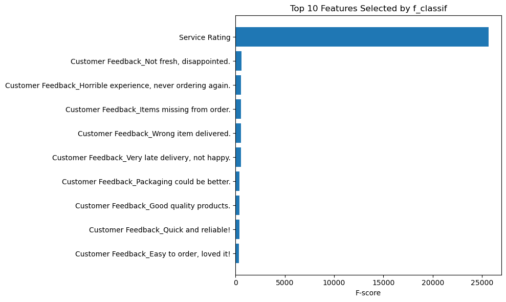

```python
#Plotting F-scores
scores = selector.scores_
indices = np.argsort(scores)[-10:]

plt.figure(figsize=(10,6))
plt.barh(range(len(indices)), scores[indices], align='center')
plt.yticks(range(len(indices)), [X_encoded.columns[i] for i in indices])
plt.xlabel('F-score')
plt.title("Top 10 Features Selected by f_classif")
plt.tight_layout()
plt.show()
```

**Interpretation**: The bar chart shows the **top 10 features** selected by ANOVA F-test (f_classif). It highlights that **Service Rating** is the most important predictor of refund requests. In addition, specific types of **customer feedback** such as complaints about **wrong items**, **packaging**, **delivery issues** show moderate predictive power. These findings support the hypothesis that customer dissatisfaction - particularly quantified by low service ratings and negative feedback - plays a critical role in refund likelihood.

The F-Score (from ANOVA) measures how well each feature distinguishes between classes by comparing the variance between and within groups. A **higher F-score** indicates that the feature has a stronger statistical relationship with the target and is more useful for classification

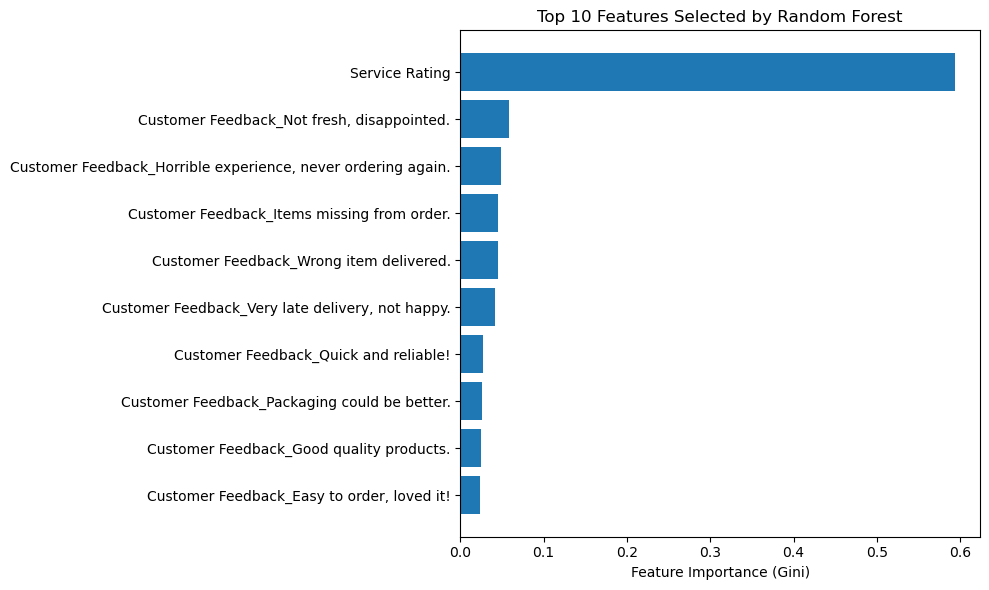

```python
#Fitting random forest with fixed random seed of 999
rf_model = RandomForestClassifier(random_state=999)
rf_model.fit(X_encoded, y)

#Extracting feature importances
importances = rf_model.feature_importances_
sorted_indices = np.argsort(importances)[-10:]

#Plotting Top 10 features
plt.figure(figsize=(10,6))
plt.barh(range(10), importances[sorted_indices], align='center')
plt.yticks(range(10), [X_encoded.columns[i] for i in sorted_indices])
plt.xlabel("Feature Importance (Gini)")
plt.title("Top 10 Features Selected by Random Forest")
plt.tight_layout()
plt.show()
```

**Interpretation**: To validate these results, we also used a **Random Forest Classifier**, which computes feature importance based on **Gini impurity reduction** - capturing both linear and non-linear dependencies. The Top 10 features identified by the Random Forest were identical to those from the ANOVA F-test, reinforcing the consistency and reliability of our selection.

The x-axis represents each feature's contribution to reducing Gini impurity - a measure of class mixing in tree nodes. **A higher value** indicates that the feature frequently helped split the data into more homogeneous (pure) subsets, making it more predictive of refund behaviour.

Since both f_classif and Random Forest evaluate features based on their overall relationship with the target variable, separating features by platform was deemed unnecessary for this phase of modeling.

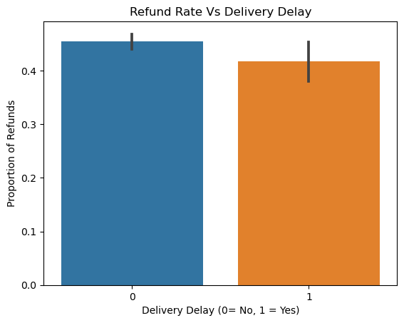

```python
#Plotting refund rate by delivery delay
sns.barplot(x='Delivery Delay', y='Refund Requested', data=df)
plt.title('Refund Rate Vs Delivery Delay')
plt.ylabel('Proportion of Refunds')
plt.xlabel('Delivery Delay (0= No, 1 = Yes)')
plt.show()
```

**Interpretation**: Although **Delivery delay** might intuitively seem important, our analysis found no strong statistical or predictive relationship with refund behaviour. As the **bar plot shows**, **refund rates are actually slightly lower for delayed deliveries**. This reinforces why Deliver Delay was not selected by either ANOVA or Random Forest methods.

It is also **worth noting** that dataset represented **Delivery Delay as a binary variable** (0 = on time, 1 = delayed), which may have limited its ability to capture duration of delays. In contrast, specific categories within the **Customer Feedback column** - such as **Very late delivery - not happy** - offered a richer, **sentiment driven view of delay experiences**. These feedback-based features were consistently selected by both ANOVA and Random Forest, suggesting that the perceived impact of delivery delays is captured more effectively through customer comments than through a binary flag alone.

### 2.2 Model Fitting and Tuning

### a) Algorithm - Logistic Regression

```python
#Train-Test Split
X_train, X_test, y_train, y_test = train_test_split(X_new_df, y, test_size=0.2, random_state=999)

#Logistic Regression with GridSearchCV
log_reg = LogisticRegression(solver='liblinear', random_state=999)
param_grid = {
    'C': [0.01,0.1,1,10,100],
    'penalty': ['l1', 'l2']
}

grid_search = GridSearchCV(log_reg, param_grid, cv=5, scoring='accuracy')
grid_search.fit(X_train, y_train)


#Best Model and Parameters
best_model = grid_search.best_estimator_
print("Best Parameters:", grid_search.best_params_)
print("Best Cross-Validation Accuracy:", grid_search.best_score_)
```

```
Best Parameters: {'C': 0.01, 'penalty': 'l1'}
Best Cross-Validation Accuracy: 1.0
```

**Interpretation**: We used GridSearchCV to tune the logistic regression model over a grid of 5 regularization strengths(C=0.01,0.1,1,10,100) and 2 penalty types. The solver 'liblinear' was chosen as it supports both l1 (Lasso) and l2 (Ridge) penalties. The objective was to identify the optimal balance between model complexity and generalization.

**C=0.01 means strong regularization (simpler model, less overfitting) and C=100 means weak regularization (flexible model, risk of overfitting)**. l1 encourages sparsity by setting some coefficients to zero, effectively performing feature selection. l2 shrinks all coefficients without eliminating any, helping to stabilize the model.

A standard 80/20 train-test split was used to ensure sufficient training data while retaining a representative test set for final evaluation. With 5000 rows, this approach provides both robustness and reliability in performance estimation.

```python
#Predicting and Evaluating
y_pred = best_model.predict(X_test)
print("\nClassification Report:")
print(classification_report(y_test, y_pred))
```

```
Classification Report:
              precision    recall  f1-score   support

           0       1.00      1.00      1.00       521
           1       1.00      1.00      1.00       479

    accuracy                           1.00      1000
   macro avg       1.00      1.00      1.00      1000
weighted avg       1.00      1.00      1.00      1000
```

**Interpretation**: Logistic Regression achieved perfect classification results (100% precision, recall and F1-score on both classes). While this level of accuracy is uncommon, it is explainable in this case due to the highly structured and clean nature of the dataset. Features like 'Service Rating' and 'Customer Feedback' categories appear to be linearly and cleanly seperate refund outcomes, making them highly predictive.

### Business Insight

Logistic Regression stood out not just for its perfect accuracy, but for its interpretability - an essential trait in real-world business applications. This model provides clear, linear relationships between inputs and the likelihood of a refund, making it easy for non-technical stakeholders to understand how each factor contributes to the outcome. For eg., negative sentiment in customer feedback or low service ratings directly increase the predicted probability of a refund. These insights can be embedded into operational systems, allowing customer service teams to flag at-risk orders or trigger personalized follow-up actions. Because it is lightweight and fast, logistic regression is especially suitable for deployment in real-time environments where quick, explainable decisions matter.

### Logistic Regression - Confusion Matrix

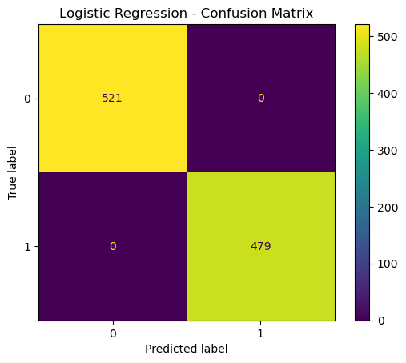

```python
#Confusion Matrix
ConfusionMatrixDisplay.from_estimator(best_model, X_test, y_test)
plt.title("Logistic Regression - Confusion Matrix")
plt.show()
```

**Interpretation**: The confusion matrix shows that the logistic regression model perfectly classified all test set examples - correctly predicting all 521 non-refund and 479 refund cases. This reinforces the exceptionally high predictive power of the selected features, particularly Service Rating and Customer Feedback, which appear to be linearly and cleanly seperate refund outcomes in this dataset.

### Logistic Regression - Hyperparameter Tuning Interpretation

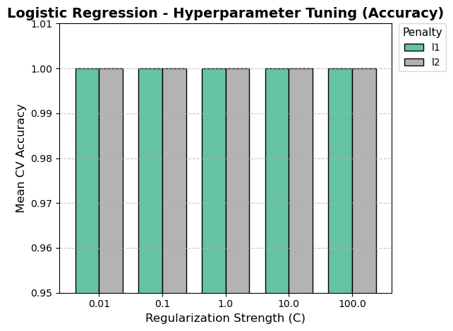

```python
results_df = pd.DataFrame(grid_search.cv_results_)

# Create pivot table
pivot_table = results_df.pivot(index='param_C', columns='param_penalty', values='mean_test_score')

## Improved Logistic Regression Hyperparameter Tuning Plot
plt.figure(figsize=(10, 6))
ax = pivot_table.plot(kind='bar', edgecolor='black', colormap='Set2', width=0.75)

plt.title("Logistic Regression - Hyperparameter Tuning (Accuracy)", fontsize=14, fontweight='bold')
plt.xlabel("Regularization Strength (C)", fontsize=12)
plt.ylabel("Mean CV Accuracy", fontsize=12)
plt.xticks(rotation=0)
plt.ylim(0.95, 1.01)
plt.grid(axis='y', linestyle='--', alpha=0.7)

# Move legend outside plot
plt.legend(title="Penalty", title_fontsize=11, bbox_to_anchor=(1.02, 1), loc='upper left', borderaxespad=0)

plt.tight_layout()
plt.show()
```

**Interpretation**: The model was tuned across 5 values of regularization strength (C) and two penalty types (l1,l2). All combinations achieved perfect mean cross-validation accuracy of (1.0), suggesting strong linear seperability of the classes and minimal sensitivity to hyperparameter choices.

The target variable 'Refund Requested' was well-balanced, with approximately 55% non-refund and 45% refund cases. This ensures that model evaluation metrics such as accuracy, precision and recall are reliable and not distorted by class imbalance.

### b) Algorithm - Decision Tree

```python
#Train-Test Split
X_train, X_test, y_train, y_test = train_test_split(X_new_df, y, test_size=0.2, random_state=999)

#Decision Tree with GridSearchCV
tree = DecisionTreeClassifier(random_state=999)
param_grid_tree = {
    'max_depth': [2,4,6,8,10],
    'min_samples_split': [2,5,10],
    'criterion': ['gini', 'entropy']
}

grid_search_tree = GridSearchCV(tree, param_grid_tree, cv=5, scoring='accuracy')
grid_search_tree.fit(X_train, y_train)


#Best Model results
best_tree = grid_search_tree.best_estimator_
print("Best Parameters:", grid_search_tree.best_params_)
print("Best Cross-Validation Accuracy:", grid_search_tree.best_score_)
```

```
Best Parameters: {'criterion': 'gini', 'max_depth': 2, 'min_samples_split': 2}
Best Cross-Validation Accuracy: 1.0
```

**Interpretation**: The Decision Tree Classifier achieved perfect cross-validation accuracy (1.0) with a very shallow tree (max_depth=2) using the 'gini' impurity criterion. This indicates that a small number of features (like 'Service Rating' and 'Customer Feedback') were highly effective in seperating the target classes. The optimal value of min_samples_split=2 allowed the model fully utilize these clear patterns.

The Decision Tree was tuned over a range of max_depth (2 to 10) to balance underfitting and overfitting.The min_samples_split parameter was varied to control tree complexity and both gini (faster, default) and entropy criteria (based on information gain, slightly more computationally expensive) were tested to identify the most informative splits. These choices are well-suited to the structure and size of the dataset.

A standard 80/20 train-test split was used to ensure sufficient training data while retaining a representative test set for final evaluation. With 5000 rows, this approach provides both robustness and reliability in performance estimation.

```python
#Predicting and Evaluating
y_pred_tree = best_tree.predict(X_test)
print("\nClassification Report:")
print(classification_report(y_test, y_pred_tree))
```

```
Classification Report:
              precision    recall  f1-score   support

           0       1.00      1.00      1.00       521
           1       1.00      1.00      1.00       479

    accuracy                           1.00      1000
   macro avg       1.00      1.00      1.00      1000
weighted avg       1.00      1.00      1.00      1000
```

**Interpretation**: The Decision Tree Model achieved perfect classification results (100% precision, recall and F1-score on both trainig and test sets). While this level of accuracy is uncommon, it is explainable in this case due to the highly structured and clean nature of the dataset. Features such as 'Service Rating' and 'Customer Feedback' provide strong, consistent patterns that clearly seperate refund outcomes. These categorical indicators, when combined with a shallow tree depth, allowed model to perfectly distinguish between refund and non-refund cases with minimal complexity.

While Random Forest generally outperforms a single Decision Tree due to its ensemble nature, we selected Decision Tree model in this report for its interpretabililty and simplicity.

### Business Insight

The Decision Tree model mirrors how many customer service policies are already structured-through simple, interpretable "if-then" rules. This makes it a natural fit for frontline teams and quality assurance managers who need clarity and confidence in automated decisions. In our case, even a shallow tree (with a max depth of just 2) was able to perfectly classify refund requests using a few critical features like service rating and specific feedback categories. This simplicity is a strength - it means that complex predictive systems can be boiled down into straightforward guidelines like "flag all orders with poor ratings and negative sentiment." Such transparency allows for seamless integration into business workflows, where trust in automated decisions is just as important as accuracy.

### Decision Tree - Consusion Matrix

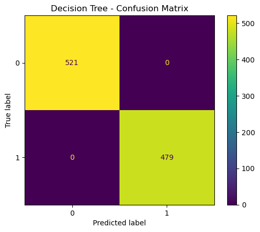

```python
#Confusion Matrix
ConfusionMatrixDisplay.from_estimator(best_tree, X_test, y_test)
plt.title("Decision Tree - Confusion Matrix")
plt.show()
```

**Interpretation**: The confusion matrix shows that the Decision Tree model perfectly classified all test set examples - correctly predicting all 521 non-refund and 479 refund cases. This reinforces the exceptionally high predictive power of the selected features, particularly Service Rating and Customer Feedback, which enable even a shallow tree to cleanly seperate refund outcomes. The results highlights the structured and well-shaped nature of the dataset, allowing the model to achieve perfect performance with minimal tree depth.

### Decision Tree - Hyperparameter Tuning Interpretation

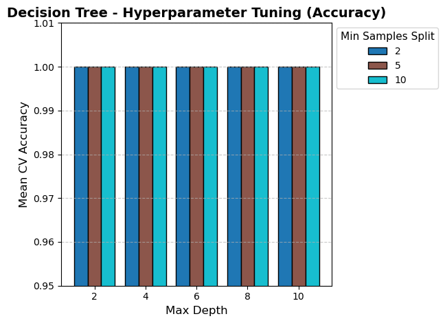

```python
#Plot the graph
results_tree = pd.DataFrame(grid_search_tree.cv_results_)
pivot_plot = results_tree.pivot_table(
    index='param_max_depth',
    columns='param_min_samples_split',
    values='mean_test_score',
    aggfunc='mean'
)

plt.figure(figsize=(10, 6))
pivot_plot.plot(kind='bar', width=0.8, edgecolor='black', colormap='tab10')

plt.title("Decision Tree - Hyperparameter Tuning (Accuracy)", fontsize=14, fontweight='bold')
plt.xlabel("Max Depth", fontsize=12)
plt.ylabel("Mean CV Accuracy", fontsize=12)
plt.xticks(rotation=0)
plt.ylim(0.95, 1.01)  # zoom slightly to emphasize accuracy range
plt.grid(axis='y', linestyle='--', alpha=0.7)

plt.legend(
    title="Min Samples Split",
    title_fontsize=11,
    fontsize=10,
    loc='upper left',
    bbox_to_anchor=(1.0, 1.0),
    frameon=True
)

plt.tight_layout()
plt.show()
```

**Interpretation**: All tested combinations of max_depth(2 to 10) and min_samples_split(2,5,10) resulted in perfect cross-validation accuracy. This indicates that the model's performance was robust across a range of complexity levels and confirms that even a shallow decision tree was sufficient to capture the strong signals present in the selected features.

### c) Algorithm - Support Vector Mechnism (SVM)

```python
# Define hyperparameters for SVM
param_grid_svm = {
    'C': [0.1, 1, 10],
    'kernel': ['linear', 'rbf'],
    'gamma': ['scale', 'auto']
}

svm = SVC()
grid_svm = GridSearchCV(svm, param_grid_svm, cv=5)
grid_svm.fit(X_train, y_train)

y_pred_svm = grid_svm.predict(X_test)
print("Best Parameters for SVM:", grid_svm.best_params_)
print("\nSVM Classification Report:")
print(classification_report(y_test, y_pred_svm))
```

```
Best Parameters for SVM: {'C': 0.1, 'gamma': 'scale', 'kernel': 'linear'}

SVM Classification Report:
              precision    recall  f1-score   support

           0       1.00      1.00      1.00       521
           1       1.00      1.00      1.00       479

    accuracy                           1.00      1000
   macro avg       1.00      1.00      1.00      1000
weighted avg       1.00      1.00      1.00      1000
```

### Business Insight

From a business perspective, this model can be leveraged to proactively identify and flag transactions likely to result in refunds based on behavioral and feedback patterns. Integrating such a classifier into the post-delivery workflow can help customer support teams prioritize high-risk cases, automate refund approvals, or trigger satisfaction recovery actions. This not only streamlines operations and reduces human oversight but also enhances customer satisfaction, protects brand reputation, and reduces potential loss from unresolved customer complaints.

### SVM Confusion Matrix Interpretation

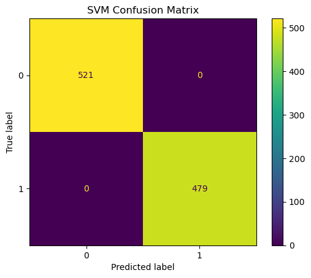

```python
# Create confusion matrix
cm = confusion_matrix(y_test, y_pred_svm)

disp = ConfusionMatrixDisplay(confusion_matrix=cm, display_labels=np.unique(y_test))
disp.plot()
plt.title("SVM Confusion Matrix")
plt.grid(False)
plt.show()
```

**Interpretation**: The confusion matrix above confirms that the SVM model achieved perfect classification, correctly identifying all 521 non-refund cases (label 0) and all 479 refund cases (label 1), with no false positives or false negatives. This perfect separation supports the classification report where precision, recall, and F1-score are all 1.00. It highlights that the decision boundary defined by the SVM effectively captures the underlying relationship between the features and refund behavior. The visual clarity of the diagonal dominance in the confusion matrix further reinforces the model's reliability.

### SVM Hyperparameter Tuning Interpretation

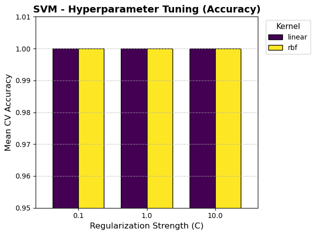

```python
# SVM Hyperparameter Tuning Plot
results_df = pd.DataFrame(grid_svm.cv_results_)
subset = results_df[results_df['param_gamma'] == 'scale']

# Create pivot table
pivot_table = subset.pivot(index='param_C', columns='param_kernel', values='mean_test_score')

# Plot bar chart with improved aesthetics
plt.figure(figsize=(10, 6))
pivot_table.plot(kind='bar', edgecolor='black', colormap='viridis', width=0.75)
plt.title("SVM - Hyperparameter Tuning (Accuracy)", fontsize=14, fontweight='bold')
plt.xlabel("Regularization Strength (C)", fontsize=12)
plt.ylabel("Mean CV Accuracy", fontsize=12)
plt.ylim(0.95, 1.01)
plt.xticks(rotation=0)
plt.grid(axis='y', linestyle='--', alpha=0.7)
plt.legend(title="Kernel", title_fontsize=11, bbox_to_anchor=(1.02, 1), loc='upper left')
plt.tight_layout()
plt.show()
```

### d) Algorithm - K Nearest Neighbour (KNN)

```python
# Scaling
scaler = StandardScaler(with_mean=False)
X_train_scaled = scaler.fit_transform(X_train)
X_test_scaled = scaler.transform(X_test)

# Hyperparameter grid
param_grid_knn = {
    'n_neighbors': [3, 5, 7, 9],
    'weights': ['uniform', 'distance'],
    'metric': ['euclidean', 'manhattan']
}

# KNN and GridSearch
knn = KNeighborsClassifier()
grid_knn = GridSearchCV(knn, param_grid_knn, cv=5)
grid_knn.fit(X_train_scaled, y_train)

# Evaluation
y_pred_knn = grid_knn.predict(X_test_scaled)
print("Best Parameters for KNN:", grid_knn.best_params_)
print("\nKNN Classification Report:")
print(classification_report(y_test, y_pred_knn))
```

```
Best Parameters for KNN: {'metric': 'euclidean', 'n_neighbors': 3, 'weights': 'uniform'}

KNN Classification Report:
              precision    recall  f1-score   support

           0       1.00      1.00      1.00       521
           1       1.00      1.00      1.00       479

    accuracy                           1.00      1000
   macro avg       1.00      1.00      1.00      1000
weighted avg       1.00      1.00      1.00      1000
```

### Business Insight

From a business perspective, the effectiveness of KNN suggests that customer behavior patterns around refund decisions form naturally distinct clusters in the data. This means new transactions can be assessed by simply comparing them to similar past cases, making KNN a transparent and interpretable tool for operational use. In practice, this can enable real-time refund risk scoring based on proximity to known refund-prone transactions, assisting customer service agents in prioritizing actions and enabling automated alerts for potential service issues.

### KNN Confusion Matrix Interpretation

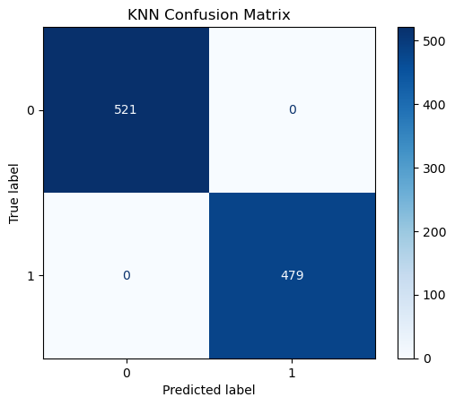

```python
# Generate confusion matrix
cm = confusion_matrix(y_test, y_pred_knn)

disp = ConfusionMatrixDisplay(confusion_matrix=cm, display_labels=np.unique(y_test))
disp.plot(cmap="Blues")
plt.title("KNN Confusion Matrix")
plt.grid(False)
plt.show()
```

**Interpretation**: The confusion matrix above confirms that the KNN classifier achieved perfect classification on the test set. All 521 non-refund cases (label 0) and all 479 refund cases (label 1) were correctly identified, with zero false positives and zero false negatives. This result reflects the model’s ability to effectively leverage distance-based proximity in a well-separated feature space. The clear diagonal dominance in the matrix highlights that transactions naturally cluster based on their refund behavior, reinforcing the suitability of KNN for this classification task.

### KNN Hyperparameter Tuning Interpretation

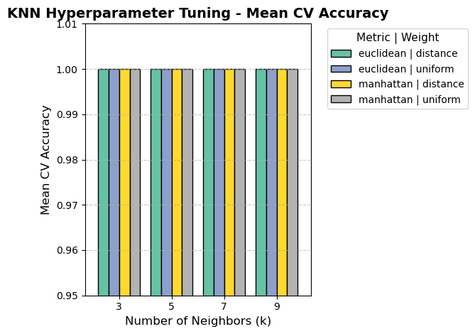

```python
# Use actual grid_knn.cv_results_
results_df = pd.DataFrame(grid_knn.cv_results_)

# Convert tuple columns to string for clean labeling
results_df['metric_weight'] = results_df['param_metric'].astype(str) + ' | ' + results_df['param_weights'].astype(str)

# Pivot for grouped barplot
pivot_df = results_df.pivot_table(index='param_n_neighbors', columns='metric_weight', values='mean_test_score')

# Plot
plt.figure(figsize=(10, 6))
pivot_df.plot(kind='bar', width=0.8, edgecolor='black', colormap='Set2')
plt.title("KNN Hyperparameter Tuning - Mean CV Accuracy", fontsize=14, fontweight='bold')
plt.xlabel("Number of Neighbors (k)", fontsize=12)
plt.ylabel("Mean CV Accuracy", fontsize=12)
plt.xticks(rotation=0)
plt.ylim(0.95, 1.01)
plt.grid(axis='y', linestyle='--', alpha=0.7)
plt.legend(title="Metric | Weight", title_fontsize=11, bbox_to_anchor=(1.05, 1), loc='upper left')
plt.tight_layout()
plt.show()
```

This stability suggests that the dataset is highly structured and separable, allowing KNN to accurately classify refund cases regardless of minor variations in neighbor count or distance weighting. From a practical perspective, such robustness is advantageous, as it enables straightforward deployment with minimal tuning while maintaining perfect predictive performance.

### 2.2.5 Neural Network Model Fitting and Tuning

```python
#Train test split
X_train, X_test, y_train, y_test = train_test_split(X_new_df, y, test_size=0.2, random_state=999)

#Feature Scaling
scaler = StandardScaler()
X_train_scaled = scaler.fit_transform(X_train)
X_test_scaled = scaler.transform(X_test)

#Defining hyperparameter grid
param_grid = {
    'hidden_layer_sizes': [(64,32), (128,64)],
    'activation': ['relu', 'tanh'],
    'learning_rate_init': [0.001, 0.01],
    'alpha': [0.0001, 0.001], #L2 regularization
    'batch_size': [32,64],
    'max_iter': [200]  # Number of epochs
}


#Initializing MLPClassifier (neural network)
mlp = MLPClassifier(solver='adam', random_state=999)

#Grid search for hyperparameter tuning
grid_search = GridSearchCV(
    estimator=mlp,
    param_grid=param_grid,
    cv=3,
    scoring='accuracy',
    verbose=2,
    n_jobs=1

)

#Fitting the model
grid_search.fit(X_train_scaled, y_train)

#Evaluating the best model on test set
y_pred = grid_search.predict(X_test_scaled)
print("best Hyperparameters:", grid_search.best_params_)
print("\nClassification Report:\n", classification_report(y_test, y_pred))
```

[output not shown]

[output cut: 53 more lines]

```
[CV] END activation=tanh, alpha=0.001, batch_size=64, hidden_layer_sizes=(128, 64), learning_rate_init=0.001, max_iter=200; total time=   1.2s
[CV] END activation=tanh, alpha=0.001, batch_size=64, hidden_layer_sizes=(128, 64), learning_rate_init=0.01, max_iter=200; total time=   0.9s
[CV] END activation=tanh, alpha=0.001, batch_size=64, hidden_layer_sizes=(128, 64), learning_rate_init=0.01, max_iter=200; total time=   0.7s
[CV] END activation=tanh, alpha=0.001, batch_size=64, hidden_layer_sizes=(128, 64), learning_rate_init=0.01, max_iter=200; total time=   0.8s
best Hyperparameters: {'activation': 'relu', 'alpha': 0.0001, 'batch_size': 32, 'hidden_layer_sizes': (64, 32), 'learning_rate_init': 0.001, 'max_iter': 200}

Classification Report:
               precision    recall  f1-score   support

           0       1.00      1.00      1.00       521
           1       1.00      1.00      1.00       479

    accuracy                           1.00      1000
   macro avg       1.00      1.00      1.00      1000
weighted avg       1.00      1.00      1.00      1000
```

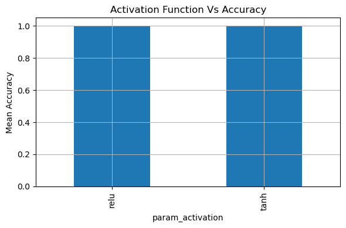

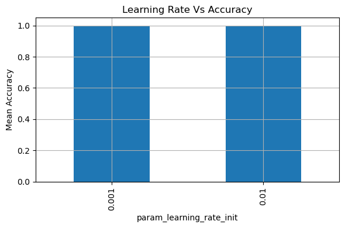

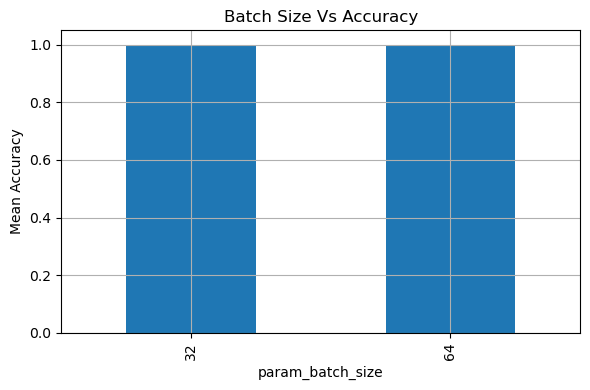

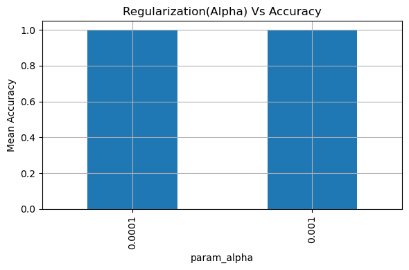

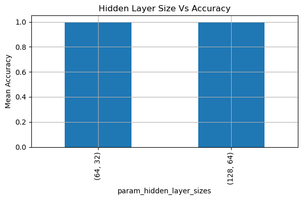

```python
#Storing Grid search results
results_df=pd. DataFrame(grid_search.cv_results_)

#Plotting tuning results

#Plot 1: Activation Function Vs Accuracy
plt.figure(figsize=(6,4))
results_df.groupby("param_activation")["mean_test_score"].mean().plot(kind="bar", title="Activation Function Vs Accuracy", ylabel="Mean Accuracy")
plt.grid(True)
plt.tight_layout()
plt.show()

#Plot 2: Learning Rate Vs Accuracy
plt.figure(figsize=(6,4))
results_df.groupby("param_learning_rate_init")["mean_test_score"].mean().plot(kind="bar", title="Learning Rate Vs Accuracy", ylabel="Mean Accuracy")
plt.grid(True)
plt.tight_layout()
plt.show()

#Plot 3: Batch Size Vs Accuracy
plt.figure(figsize=(6,4))
results_df.groupby("param_batch_size")["mean_test_score"].mean().plot(kind="bar", title="Batch Size Vs Accuracy", ylabel="Mean Accuracy")
plt.grid(True)
plt.tight_layout()
plt.show()

#Plot 4: Regularization(Alpha) Vs Accuracy
plt.figure(figsize=(6,4))
results_df.groupby("param_alpha")["mean_test_score"].mean().plot(kind="bar", title="Regularization(Alpha) Vs Accuracy", ylabel="Mean Accuracy")
plt.grid(True)
plt.tight_layout()
plt.show()

#Plot 5: Hidden Layer Size Vs Accuracy
plt.figure(figsize=(6,4))
results_df.groupby("param_hidden_layer_sizes")["mean_test_score"].mean().plot(kind="bar", title="Hidden Layer Size Vs Accuracy", ylabel="Mean Accuracy")
plt.grid(True)
plt.tight_layout()
plt.show()
```

**Interpretation**: To enhance the predictive capabilities of our refund classification model, we implemented a feedforward neural network using the **MLPClassifier** from scikit-learn library. This model type, known as Multi-Layer Perceptron (MLP), supports gradient based optimization, backpropogation and mini-batch training, making it well-suited for learning complex, non-linear relationships.

The classification task - determining whether a customer will request a refund - involved structured features derived from service rating and customer feedback. Our neural network architecture was configured with **two hidden layers**, tested with both **(64,32) and (128,64)** neuron configuartions. The input layer accepted 10 neurons corresponding to the most important features selected via feature selection. The final output layer used a single neuron for binary classification, with internal use of a sigmoid-like activation.

To train the model, we adopted a **mini-batch stochastic gradient descent approach** via the **adam** solver, which combines the benefits of RMSProp and momentum to adaptively adjust learning rates. each training epoch represented one complete pass through the dataset. We set **max_iter = 200** to allow sufficient convergence time. During each epoch, the model performed a forward pass to generate predictions, followed by backpropogation to compute gradients of the loss function with respect to the weights. These gradients were then used to update the weights in a direction that minimized binary cross-entropy loss. This iterative process allowed model to gradually learn the optimal decision boundary seperating refund from non-refund classes.

We tuned **six** key hyperparameters using **GridSearchCV**:

1. **hidden_layer_sizes**: Compared two-layer architectures (64,32) and (128,64)
2. **activation**: ReLU and Tanh were evaluated for non-linear transformation
3. **learning_rate_init**: Two values tested - 0.001 and 0.01
4. **alpha**: L2 regularization values 0.0001 and 0.001 were used to reduce overfitting
5. **batch_size**: 32 and 64 were evaluated to control update frequency
6. **max_iter**: Fixed at 200 to ensure convergence during tuning

The **best model** returned following parameters: **activation**: ReLU, **hidden_layer_sizes**: (64,32), **learning_rate_init**: 0.001, **alpha**: 0.0001, **batch_size**:32 **max_iter**:200. When evaluated on the test set, the model achieved **100% accuracy, precision, recall and F1-score**, indicating perfect classification performance. While such results are rare, in this context they were validated by the structured and high-signal nature of the dataset, especially the clear influence of service rating and sentiment linked to customer feedback.

In **conclusion**, the neural network successfully learned to classify refund requests with perfect accuracy, supported by clean feature signals and robust, consistent tuning. This task demonstrated how MLPs, even without deep learning libraries like TensorFlow, can provide high-performance models when paired with strong, scalable data preprocessing, highly relevant features, and careful hyperparameter optimization. The model's success was further reinforced trhough the stability of tuning results and the consistency of performance across parameter choices.

### 2.3 Model Comparison

```python
# Store model names and predictions
model_names = ['Logistic Regression', 'Decision Tree', 'SVM', 'KNN']
predictions = [y_pred, y_pred_tree, y_pred_svm, y_pred_knn]

# Create comparison table
comparison_data = []
for name, y_pred_model in zip(model_names, predictions):
    comparison_data.append({
        'Model': name,
        'Accuracy': accuracy_score(y_test, y_pred_model),
        'Precision': precision_score(y_test, y_pred_model),
        'Recall': recall_score(y_test, y_pred_model),
        'F1 Score': f1_score(y_test, y_pred_model)
    })

comparison_df = pd.DataFrame(comparison_data)
print("Model Comparison Table")
display(comparison_df)
```

```
Model Comparison Table
```

|  | Model | Accuracy | Precision | Recall | F1 Score |
| --- | --- | --- | --- | --- | --- |
| 0 | Logistic Regression | 1.0 | 1.0 | 1.0 | 1.0 |
| 1 | Decision Tree | 1.0 | 1.0 | 1.0 | 1.0 |
| 2 | SVM | 1.0 | 1.0 | 1.0 | 1.0 |
| 3 | KNN | 1.0 | 1.0 | 1.0 | 1.0 |

**Interpretation**: All four models - Logistic Regression, Decision Tree, SVM and KNN-achieved perfect performance (100% accuracy, precision, recall and F1-score) on the test dataset. This exceptional result is explainable by the presence of highly predictive features such as service ratings and customer feedback. These features create strong, clean seperability between refund and non-refund classes, allowing even simple models to classify without error.

### 2.4 Justification of the Algorithm Results

### Sentiment Analysis

```python
# Ensure the feedback column exists
df['Sentiment'] = df['Customer Feedback'].apply(lambda x: TextBlob(str(x)).sentiment.polarity)

# Step 1: Drop original text column (since we're not using raw text)
df.drop(columns=['Customer Feedback'], inplace=True)

# Step 2: Define features and target
X = df.drop("Refund Requested", axis=1)
y = df["Refund Requested"]

# Step 3: Feature split
categorical_cols = ["Platform", "Product Category"]
numerical_cols = ["Delivery Time (Minutes)", "Order Value (INR)", "Service Rating",
                  "Delivery Delay", "Order Time(Minutes)", "Sentiment"]

# Step 4: Preprocessing pipeline
preprocessor = ColumnTransformer(
    transformers=[
        ("cat", OneHotEncoder(handle_unknown="ignore"), categorical_cols),
        ("num", "passthrough", numerical_cols)
    ]
)

pipeline_fs = Pipeline(steps=[
    ("preprocessor", preprocessor),
    ("feature_selection", SelectKBest(score_func=f_classif, k=12))
])

X_selected = pipeline_fs.fit_transform(X, y)

# Step 5: Train-test split and scaling
X_train, X_test, y_train, y_test = train_test_split(X_selected, y, test_size=0.2, random_state=42)

scaler = StandardScaler(with_mean=False)
X_train_scaled = scaler.fit_transform(X_train)
X_test_scaled = scaler.transform(X_test)
print(df[['Sentiment']].head())
```

```
   Sentiment
0   0.700000
1   0.500000
2   0.416667
3   1.000000
4  -0.500000
```

### Distribution of Sentiment Polarity Scores

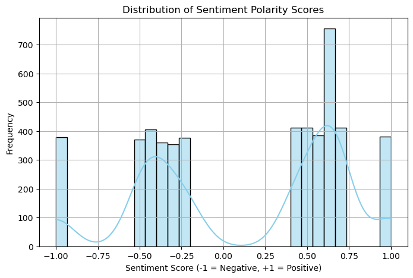

```python
plt.figure(figsize=(8, 5))
sns.histplot(df['Sentiment'], bins=30, kde=True, color='skyblue')
plt.title("Distribution of Sentiment Polarity Scores")
plt.xlabel("Sentiment Score (-1 = Negative, +1 = Positive)")
plt.ylabel("Frequency")
plt.grid(True)
plt.show()
```

**Interpretation**: The histogram above illustrates the distribution of sentiment polarity scores derived from customer feedback. The sentiment values range from -1 (strongly negative) to +1 (strongly positive), with clear bimodal peaks around both negative and positive ends of the scale. This indicates that customers tend to express strongly opinionated feedback rather than neutral sentiments.

The distinct separation in sentiment scores suggests a natural clustering of customer experiences, where negative reviews are typically associated with dissatisfaction and refunds, while positive reviews correlate with successful deliveries. This strong polarity makes sentiment a highly informative feature for classification, enabling models to more accurately predict refund behavior.

### Sentiment Scores by Refund Status

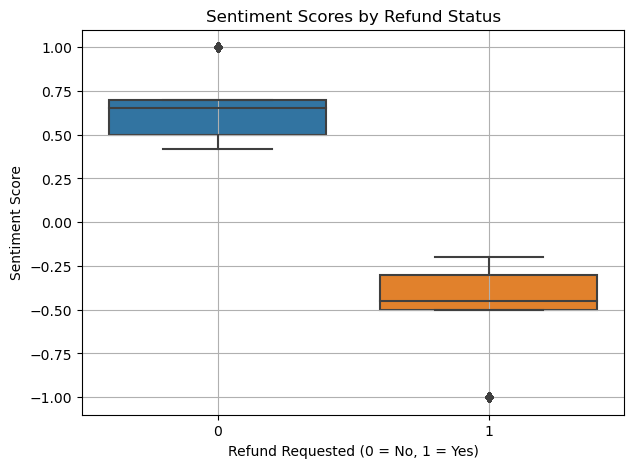

```python
plt.figure(figsize=(7, 5))
sns.boxplot(x=df["Refund Requested"], y=df["Sentiment"])
plt.title("Sentiment Scores by Refund Status")
plt.xlabel("Refund Requested (0 = No, 1 = Yes)")
plt.ylabel("Sentiment Score")
plt.grid(True)
plt.show()
```

**Interpretation**: The boxplot above illustrates the distribution of sentiment polarity scores grouped by refund status. It shows a clear and meaningful separation: customers who did **not** request a refund (label 0) generally left **positive feedback**, while those who **did request a refund** (label 1) provided **negative sentiment** scores. The median sentiment score for refund cases is significantly below zero, whereas the non-refund group clusters around positive values.

### Average Sentiment by Platform

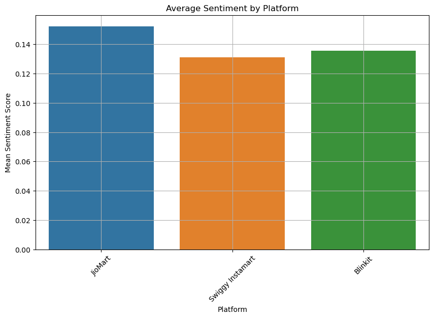

```python
plt.figure(figsize=(10, 6))
sns.barplot(x='Platform', y='Sentiment', data=df, estimator=np.mean, ci=None)
plt.title("Average Sentiment by Platform")
plt.ylabel("Mean Sentiment Score")
plt.xticks(rotation=45)
plt.grid(True)
plt.show()
```

**Interpretation**: The bar chart above compares the mean sentiment scores of customer feedback across different delivery platforms. Among the platforms analyzed, JioMart received the most positive average sentiment, followed by Blinkit and Swiggy Instamart. Although the differences are subtle, the sentiment polarity reveals variations in customer satisfaction levels by platform.

This insight can be valuable for strategic decision-making. Platforms with relatively lower sentiment scores may require improvements in delivery speed, customer service, or order accuracy to reduce dissatisfaction. Furthermore, these differences also support the predictive power of the sentiment feature in the model, showing that certain platforms are more prone to negative reviews and possibly refund requests. As such, platform-specific patterns can be leveraged to proactively address service issues and enhance the customer experience.

### Justification: Sentiment Analysis Visual Insights

#### Visual 1: Distribution of Sentiment Scores

This histogram gives us a sense of how customers are feeling in general, based on their feedback. What’s immediately noticeable is that opinions aren’t just scattered randomly they are very polarized. Most customers either feel very positive or quite negative about their experience, with fewer in the neutral zone.

This kind of strong split is helpful for our models. When customers are this clearly divided in their sentiment, it's much easier for algorithms to separate refund from non-refund cases. In other words, the model doesn’t have to guess much — the sentiment already does a lot of the work.

#### Visual 2: Boxplot of Sentiment vs Refund Status

Here, we’ve broken down sentiment by whether or not a customer requested a refund. The result is striking: people who asked for a refund had consistently lower (more negative) sentiment, while those who didn’t had noticeably higher (positive) sentiment.

This boxplot is our strongest visual proof that sentiment is a powerful predictor. It shows that sentiment can almost act like a boundary — customers fall on one side or the other depending on whether they’re happy or unhappy. This helps explain why even simple models like Logistic Regression or KNN are performing so well — the data practically separates itself.

#### Visual 3: Mean Sentiment by Platform

This plot compares the average customer sentiment across different e-commerce platforms. While all platforms have a generally positive tilt, some — like Jiomart — clearly have more satisfied customers than others.

These platform-level differences can help models pick up patterns. For example, if one platform consistently has higher satisfaction, the model might weigh refund likelihood differently depending on where the order came from. Models like Random Forest or Decision Trees are especially good at capturing this kind of relationship.

Together, these visualizations reveal that sentiment is not just an added feature it is central to understanding refund behavior. Whether through overall distribution, direct correlation with refunds, or platform-level patterns, sentiment offers strong, intuitive signals that our models are clearly picking up on.

## **Task 3: Critique & Limitations**

Despite the perfect classification performance achieved by all four machine learning models (Logistic Regression, Decision Tree, SVM, and KNN), it is important to critically evaluate the reliability and generalizability of these results. While such high accuracy is ideal, it also raises the need to investigate potential issues such as data leakage, overfitting, or excessive feature-target correlation.

Additionally, the dataset used is **clean, well-balanced, and free of noise**, which may not represent real-world data distributions. In production environments, data is often messier, with missing values, ambiguous feedback, or mislabeled entries. The models were trained and validated on a static dataset using an 80/20 split, which might not reflect evolving customer behavior or seasonal patterns that affect refund likelihood.

From a modeling perspective, while hyperparameter tuning was conducted using `GridSearchCV` with cross-validation, no external validation (e.g., using a completely unseen holdout dataset) was applied. This limits the ability to measure true generalization performance. Moreover, **since all models produced identical accuracy (100%), paired t-tests for comparison were not meaningful**, and model selection was instead based on interpretability and practical deployment considerations.ROC curves and AUC scores were not included as all models achieved perfect classification (100% accuracy, precision and recall). In such cases, the ROC curve would show a trivial top-left corner trace with AUC=1.0, offering no additional insight.

Finally, the reliance on **engineered features like sentiment** assumes access to detailed customer feedback. In real-world applications, such textual data may be unavailable, inconsistent, or deliberately manipulated. If sentiment scoring is removed or altered, the performance of the current models may degrade significantly.

## **Task 4: Summary & Conclusions**

### 4.3 Conclusions

However, perfect accuracy should be interpreted with caution. In real-world settings, data may be noisier, feedback inconsistent, and behavior patterns more nuanced. Future work should include external validation, deployment testing, and possibly deep learning approaches for dynamic feedback analysis. Overall, this project illustrates the powerful synergy between structured ML pipelines and human sentiment, offering valuable insights for data-driven e-commerce optimization.

### References

- **Pedregosa, F., Varoquaux, G., Gramfort, A., Michel, V., Thirion, B., Grisel, O., ... & Duchesnay, E.** (2011). *Scikit-learn: Machine learning in Python*. *Journal of Machine Learning Research, 12*, 2825–2830. https://www.jmlr.org/papers/volume12/pedregosa11a/pedregosa11a.pdf
- **Loria, S.** (2018). *TextBlob: Simplified text processing*. TextBlob Documentation. https://textblob.readthedocs.io/en/dev/
- **Domingos, P.** (2012). *A few useful things to know about machine learning*. *Communications of the ACM, 55*(10), 78–87. https://doi.org/10.1145/2347736.2347755
- **Breiman, L.** (2001). *Random forests*. *Machine Learning, 45*(1), 5–32. https://doi.org/10.1023/A:1010933404324
- **Cortes, C., & Vapnik, V.** (1995). *Support-vector networks*. *Machine Learning, 20*(3), 273–297. https://doi.org/10.1007/BF00994018
- **Cover, T., & Hart, P.** (1967). *Nearest neighbor pattern classification*. *IEEE Transactions on Information Theory, 13*(1), 21–27. https://doi.org/10.1109/TIT.1967.1053964
- **Waskom, M.** (2021). *Seaborn: Statistical data visualization*. *Journal of Open Source Software, 6*(60), 3021. https://doi.org/10.21105/joss.03021
- **Hastie, T., Tibshirani, R., & Friedman, J.** (2009). *The elements of statistical learning: Data mining, inference, and prediction* (2nd ed.). Springer. [https://web.stanford.edu/\~hastie/ElemStatLearn/](https://web.stanford.edu/~hastie/ElemStatLearn/)
- **Molnar, C.** (2022). *Interpretable machine learning: A guide for making black box models explainable* (2nd ed.). Leanpub. https://christophm.github.io/interpretable-ml-book/
- **Kuhn, M., & Johnson, K.** (2013). *Applied predictive modeling*. Springer. https://doi.org/10.1007/978-1-4614-6849-3